# Homework Answers

# Homework-2023.10.23

## Question 1 (7.5)

Refer to Exercise 7.4. Compute 95% bootstrap confidence intervals for the mean time between failures $1/λ$ by the standard normal, basic, percentile, and BCa methods. Compare the intervals and explain why they may differ.

### Answer

```r
library(boot)
library(bootstrap)
x = c(3, 5, 7, 18, 43, 85, 91, 98, 100, 130, 230, 487)
set.seed(11)
b.mean <- function(x,i) mean(x[i])
de <- boot(data=x, statistic=b.mean, R = 999)
boot.ci(de,type=c("norm","basic","perc","bca"))
```

```
## BOOTSTRAP CONFIDENCE INTERVAL CALCULATIONS
## Based on 999 bootstrap replicates
##
## CALL :
## boot.ci(boot.out = de, type = c("norm", "basic", "perc", "bca"))
##
## Intervals :
## Level      Normal              Basic
## 95%   ( 35.5, 183.4 )   ( 23.6, 171.6 )
##
## Level     Percentile            BCa
## 95%   ( 44.6, 192.6 )   ( 57.9, 241.3 )
## Calculations and Intervals on Original Scale
## Some BCa intervals may be unstable
```

BCa intervals are “better” than other types of bootstrap intervals in terms of coverage.

## Question 2 (7.8)

Refer to Exercise 7.7. Obtain the jackknife estimates of bias and standard error of $\hat{\theta}$.

### Answer

```r
n <- 88
Sigma.hat = cor(scor)
lambda.hat = eigen(Sigma.hat)$values
theta.hat = lambda.hat[1]/sum(lambda.hat)
theta.jack <- numeric(n)
for(i in 1:n){
  Sigma.jack = cor(scor[(1:n)[-i],])
  lambda.jack = eigen(Sigma.jack)$values
  theta.jack[i] = lambda.jack[1]/sum(lambda.jack)
}
bias.jack <- (n-1)*(mean(theta.jack)-theta.hat)
se.jack <- sqrt((n-1)*mean((theta.jack-theta.hat)^2))

round(c(original=theta.hat,bias.jack=bias.jack,
se.jack=se.jack),3)
```

```
##  original bias.jack   se.jack
##     0.636     0.000     0.045
```

## Question 3 (7.11)

In Example 7.18, leave-one-out (n-fold) cross validation was used to select the best fitting model. Use leave-two-out cross validation to compare the models.

### Answer

```r
n <- length(magnetic) #in DAAG ironslag

# for n-fold cross validation
# fit models on leave-two-out samples
index <- t(combn(n,2))
m <- nrow(index)
e1 <- e2 <- e3 <- e4 <- numeric(m)

vec.norm <- function(x) sqrt(sum(x^2))

for (k in 1:m) {
  y <- magnetic[-index[k,]]
  x <- chemical[-index[k,]]
  J1 <- lm(y ~ x)
  yhat1 <- J1$coef[1] + J1$coef[2] * chemical[index[k,]]
  e1[k] <- vec.norm(magnetic[index[k,]] - yhat1)
  J2 <- lm(y ~ x + I(x^2))
  yhat2 <- J2$coef[1] + J2$coef[2] * chemical[index[k,]] +
  J2$coef[3] * chemical[index[k,]]^2
  e2[k] <- vec.norm(magnetic[index[k,]] - yhat2)
  J3 <- lm(log(y) ~ x)
  logyhat3 <- J3$coef[1] + J3$coef[2] * chemical[index[k,]]
  yhat3 <- exp(logyhat3)
  e3[k] <- vec.norm(magnetic[index[k,]] - yhat3)
  J4 <- lm(log(y) ~ log(x))
  logyhat4 <- J4$coef[1] + J4$coef[2] * log(chemical[index[k,]])
  yhat4 <- exp(logyhat4)
  e4[k] <- vec.norm(magnetic[index[k,]] - yhat4)
}

c(mean(e1^2), mean(e2^2), mean(e3^2), mean(e4^2))
```

```
## [1] 39.14455 35.74037 36.90983 40.93436
```

# Homework-2023.10.30

## Question 1

Proof the Stationarity of Metropolis-Hastings sampler Algorithm in continuous situation.

### Answer

Denote $x^*\sim q(x^*\mid x_i)$ and $\alpha(x_i,x^*)=\min\{1,\frac{p(x^*)q(x_i|x^*)}{p(x_i)q(x^*|x_i)}\}$.

We will prove that the transition kernel of the Markov chain holds the detailed balance condition, that is
$$p(x_i)K(x_{i+1}\mid x_i)=p(x_{i+1})K(x_i\mid
x_{i+1}),\mathrm{~}\forall(x_i,x_{i+1}).$$

The transition kernel is
$$K(x_{i+1}\mid x_i)=q(x_{i+1}\mid
x_i)\alpha(x_i,x_{i+1})+I({x_i}=x_{i+1})r(x_i),$$
where $r(x_i)=P(\text{reject }x^*)=1-\int\alpha(x_i,s)q(s\mid x_i)ds$.

**Case 1: $x_i=x_{i+1}$**

Then it is trivial that
$$p(x_i)K(x_{i+1}\mid x_i)=p(x_{i+1})K(x_i\mid
x_{i+1}),\mathrm{~}\forall(x_i,x_{i+1}).$$

**Case 2: $x_i\ne x_{i+1}$**

We have
$$\begin{align}
p(x_i)K(x_{i+1}\mid x_i)&=p(x_i)q(x_{i+1}\mid
x_i)\alpha(x_i,x_{i+1})\\
&=p(x_i)q(x_{i+1}\mid
x_i)\min\{1,\frac{p(x_{i+1})q(x_i|x_{i+1})}{p(x_i)q(x_{i+1}|x_i)}\}\\
&=\min\{p(x_i)q(x_{i+1}\mid x_i),p(x_{i+1})q(x_i|x_{i+1})\}.
\end{align}$$

We will get $p(x_{i+1})K(x_i\mid x_{i+1})=\min\{p(x_i)q(x_{i+1}\mid x_i),p(x_{i+1})q(x_i|x_{i+1})\}$ if we do the same to $p(x_{i+1})K(x_i\mid x_{i+1})$, thus the proof is concluded.

## Question 2 (Ex 8.1)

Implement the two-sample Cramer-von Mises test for equal distributions as a permutation test. Apply the test to the data in Examples 8.1 and 8.2.

### Answer

```r
cvm.test <- function(x,y){
  n = length(x)
  m = length(y)
  F_n <- ecdf(x)
  G_m <- ecdf(y)

  s1 = sum((F_n(x)-G_m(x))^2)
  s2 = sum((F_n(y)-G_m(y))^2)
  W = m*n/(m+n)^2*(s1+s2)
  return(W)
}
```

```r
library(twosamples)
attach(chickwts)
x <- sort(as.vector(weight[feed == "soybean"]))
y <- sort(as.vector(weight[feed == "linseed"]))
detach(chickwts)

W = cvm.test(x,y)
print(W)
```

```
## [1] 0.1515216
```

```r
print(cvm_test(x,y))
```

```
## Test Stat   P-Value
## 0.6096939 0.4120000
```

## Question 3 (Ex 8.3)

The Count 5 test for equal variances in Section 6.4 is based on the maximum number of extreme points. Example 6.15 shows that the Count 5 criterion is not applicable for unequal sample sizes. Implement a permutation test for equal variance based on the maximum number of extreme points that applies when sample sizes are not necessarily equal.

### Answer

```r
count5test <- function(x, y) {
  X <- x - mean(x)
  Y <- y - mean(y)
  outx <- sum(X > max(Y)) + sum(X < min(Y))
  outy <- sum(Y > max(X)) + sum(Y < min(X))
  # return 1 (reject) or 0 (do not reject H0)
  return(as.integer(max(c(outx, outy)) > 5))
}
# assume length(x)<=length(y)
count5test.ue <- function(x, y, R=999) {
  n1 <- length(x)
  n2 <- length(y)
  reps <- numeric(R)
  for (i in 1:R){
    k <- sample(1:n2, size = n1, replace = TRUE)
    y1 <- y[k]
    reps[i] = count5test(x,y1)
  }
  p <- mean(reps) > 0.5
}
```

```r
# example 6.15
n1 <- 20
n2 <- 30
mu1 <- mu2 <- 0
sigma1 <- sigma2 <- 1
m <- 1000
alphahat <- mean(replicate(m, expr={
  x <- rnorm(n1, mu1, sigma1)
  y <- rnorm(n2, mu2, sigma2)
  x <- x - mean(x) #centered by sample mean
  y <- y - mean(y)
  count5test.ue(x, y)
}))
print(alphahat)
```

```
## [1] 0.033
```

```r
sigma1 <- 1
sigma2 <- 1.5
power <- mean(replicate(m, expr={
  x <- rnorm(20, 0, sigma1)
  y <- rnorm(20, 0, sigma2)
  count5test.ue(x, y)
}))
print(power)
```

```
## [1] 0.239
```

# Homework-2023.11.06

## Question 1

Consider a model
$$P(Y=1\mid
X_1,X_2,X_3)=\frac{\exp(a+b_1X_1+b_2X_2+b_3X_3)}{1+\exp(a+b_1X_1+b_2X_2+b_3X_3)},$$
where $X_1 \sim P(1), X_2 \sim Exp(1)$ and $X_3 \sim B(1, 0.5)$.

### (1)

Design a function that takes as input values $N, b_1, b_2, b_3$ and $f_0$, and produces the output $a$.

### Answer

```r
f <- function(N,b1,b2,b3,f0){
  x1 = rpois(N,1)
  x2 = rexp(N)
  x3 = rbinom(N,1,0.5)
  obs = b1*x1 + b2*x2 + b3*x3
  g <- function(x) mean(1/(1+exp(x+obs))) + f0 - 1

  a = uniroot(g, c(-20,20))$root
  #print(g(20))
  #print(g(-20))
  return(a)
}
```

### (2)

Call this function, input values are $N = 10^6 , b_1 = 0, b_2 = 1, b_3 = −1, f_0 = 0.1, 0.01, 0.001, 0.0001$.

### Answer

```r
N = 1e6
b1 = 0
b2 = 1
b3 = -1
f0 = c(0.1, 0.01, 0.001, 0.0001)
set.seed(11)
a = numeric(4)
for (i in 1:4) {
  a[i] = f(N,b1,b2,b3,f0[i])
}
print(a)
```

```
## [1]  -3.168830  -6.075608  -8.718858 -11.234627
```

### (3)

Plot $− \log f_0$ vs $a$.

### Answer

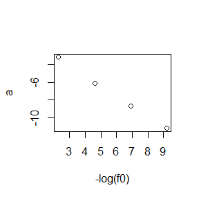

```r
plot(-log(f0),a)
```

## Question 2 (Ex 9.4)

Implement a random walk Metropolis sampler for generating the standard Laplace distribution (see Exercise 3.2). For the increment, simulate from a normal distribution. Compare the chains generated when different variances are used for the proposal distribution. Also, compute the acceptance rates of each chain.

### Answer

```r
laplace <- function(x) 0.5*exp(-abs(x))

chain <- function(sigma, n, x1){
  x = numeric(n)
  x[1] = x1
  u = runif(n)
  k = 0
  for (i in 2:n){
    xt = x[i-1]
    y = rnorm(1, xt, sigma)
    if (u[i] <= laplace(y)/laplace(xt)) x[i] = y
    else{
      x[i] = xt
      k = k+1
    }
  }
  return(list(x=x,k=k))
}
```

```r
# simulation
sigmas = c(0.05,0.5,2.5,16)
n = 2000
set.seed(111)

theta0 <- c

rw1 = chain(sigmas[1],n,50)
rw2 = chain(sigmas[2],n,50)
rw3 = chain(sigmas[3],n,50)
rw4 = chain(sigmas[4],n,50)
kk = c(rw1$k,rw2$k,rw3$k,rw4$k)
rw = rbind(rw1$x,rw2$x,rw3$x,rw4$x)
print(kk/n)
```

```
## [1] 0.0150 0.1705 0.5405 0.9060
```

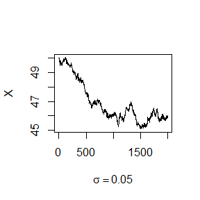

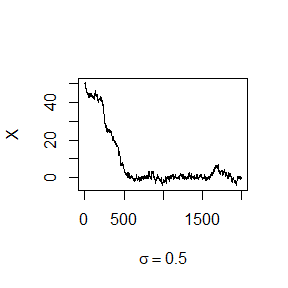

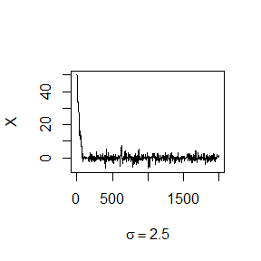

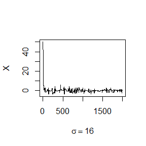

```r
for (i in 1:4){
  plot(rw[i,], type = "l", xlab=bquote(sigma == .(round(sigmas[i],3))), ylab="X", xlim=c(1,n), ylim=range(rw[i,]))
}
```

## Question 3 (Ex 9.7)

Implement a Gibbs sampler to generate a bivariate normal chain $(X_t, Y_t)$ with zero means, unit standard deviations, and correlation 0.9. Plot the generated sample after discarding a suitable burn-in sample. Fit a simple linear regression model $Y = \beta_0 + \beta_1X$ to the sample and check the residuals of the model for normality and constant variance.

### Answer

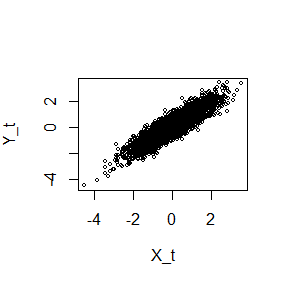

```r
set.seed(111)
n = 5000
burn = 1000
da = matrix(0,n,2)
rho = 0.9
mu1 = mu2 = 0
sigma1 = sigma2 =1
s1 = sqrt(1-rho^2)*sigma1
s2 = sqrt(1-rho^2)*sigma2

da[1,] = c(mu1,mu2)
for (i in 2:n){
  y = da[i-1,2]
  m1 = mu1 + rho*(y-mu2)*sigma1/sigma2
  da[i,1] = rnorm(1,m1,s1)
  x = da[i,1]
  m2 = mu2 + rho*(x-mu1)*sigma2/sigma1
  da[i,2] = rnorm(1,m2,s2)
}

plot(da[(burn+1):n,1],da[(burn+1):n,2],xlab = bquote(X_t),ylab = bquote(Y_t),cex=0.5)
```

```r
da.burn <- data.frame(da[(burn+1):n,])
lm(da.burn[,1]~da.burn[,2])
```

```
##
## Call:
## lm(formula = da.burn[, 1] ~ da.burn[, 2])
##
## Coefficients:
##  (Intercept)  da.burn[, 2]
##      -0.0122        0.9064
```

```r
colnames(da.burn) <- c("X","Y")
colMeans(da.burn)
```

```
##          X          Y
## 0.01047471 0.02501647
```

```r
cov(da.burn)
```

```
##           X         Y
## X 1.0356444 0.9229262
## Y 0.9229262 1.0181768
```

```r
cor(da.burn)
```

```
##           X         Y
## X 1.0000000 0.8987731
## Y 0.8987731 1.0000000
```

## Question 3 (Ex 9.10)

Refer to Example 9.1. Use the Gelman-Rubin method to monitor convergence of the chain, and run the chain until the chain has converged approximately to the target distribution according to $\hat R < 1.2$. (See Exercise 9.9.) Also use the `coda` [212] package to check for convergence of the chain by the Gelman-Rubin method. Hints: See the help topics for the `coda` functions `gelman.diag`, `gelman.plot`, `as.mcmc`, and `mcmc.list`.

### Answer

```r
library(coda)

f <- function(x,sigma){
  if (any(x < 0)) return (0)
  stopifnot(sigma > 0)
  return((x / sigma^2) * exp(-x^2 / (2*sigma^2)))
}

lap.chain <- function(m, sigma){
  x <- numeric(m)
  x[1] <- rchisq(1, df=1)
  k <- 0
  u <- runif(m)
  for (i in 2:m) {
    xt <- x[i-1]
    y <- rchisq(1, df = xt)
    num <- f(y, sigma) * dchisq(xt, df = y)
    den <- f(xt, sigma) * dchisq(y, df = xt)
    if (u[i] <= num/den) x[i] <- y else {
      x[i] <- xt
      k <- k+1 #y is rejected
    }
  }
  return(x)
}

Gelman.Rubin <- function(psi){
  psi = as.matrix(psi)
  n = ncol(psi)
  k = nrow(psi)
  psi.means = rowMeans(psi)
  B = n*var(psi.means)
  psi.w = apply(psi, 1, "var")
  W = mean(psi.w)
  v.hat = W*(n-1)/n + B/(n*k)
  r.hat = v.hat/W
  return(r.hat)
}
```

```r
m <- 10000
sigma <- 4
k = 4
burn = 1000

X = matrix(0, nrow = k, ncol = m)
for (i in 1:k){
  X[i,] = lap.chain(m,sigma)
}

psi = t(apply(X, 1, cumsum))
for (i in 1:nrow(psi))
  psi[i,] = psi[i,]/(1:ncol(psi))
print(Gelman.Rubin(psi))
```

```
## [1] 1.012734
```

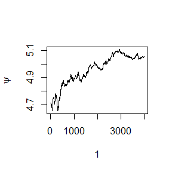

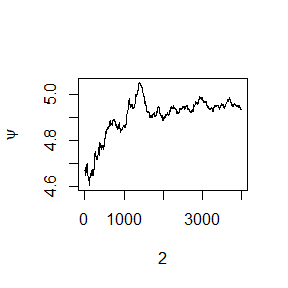

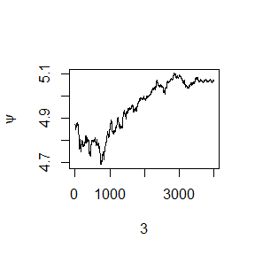

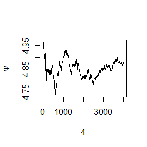

```r
for (i in 1:k){
  plot(psi[i, (burn+1):n], type="l", xlab=i, ylab=bquote(psi))
}
```

```r
la.mc = mcmc.list(as.mcmc(X[1,]),as.mcmc(X[2,]),as.mcmc(X[3,]),as.mcmc(X[4,]))

gelman.diag(la.mc)
```

```
## Potential scale reduction factors:
##
##      Point est. Upper C.I.
## [1,]          1          1
```

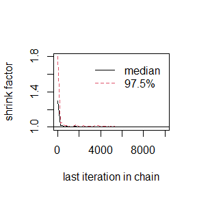

```r
gelman.plot(la.mc)
```

# Homework-2023.11.13

## Question 1

设$X_1,\cdots,X_n \sim Exp(\lambda)$独立同分布，只知道$X_i$存在某个区间$(u_i,v_i)$，其中$u_i<v_i$是两个非随机的常数。这种数据称为区间删失数据。

1. 试分别直接极大化观测数据的似然函数与采用EM算法求解$\lambda$的MLE，证明EM算法收敛于观测数据的MLE，且收敛有线性速度。
2. 设$(u_i,v_i)\ i=1,\cdots,10$的观测值为 $(11,12),(8,9),(27,28),(13,14),(16,17),(0,1),(23,24),(10,11),(24,25),(2,3)$.

分别编程实现上述两种算法得到$\lambda$的MLE的数值解。

**Hint:** $L(\lambda)=\Pi_{i=1}^n \mathbb{P}_\lambda(u_i \le X_i \le v_i)$

### Answer

**Proof of convergence**

For any $\mathbf {Z}$ with non-zero probability ${\displaystyle p(\mathbf {Z} \mid \mathbf {X} ,{\boldsymbol {\theta }})}$, we can write

$${\displaystyle \log p(\mathbf {X} \mid {\boldsymbol {\theta }})=\log
p(\mathbf {X} ,\mathbf {Z} \mid {\boldsymbol {\theta }})-\log p(\mathbf
{Z} \mid \mathbf {X} ,{\boldsymbol {\theta }}).}$$
We take the expectation over possible values of the unknown data $\mathbf {Z}$ under the current parameter estimate $\theta^{(t)}$ by multiplying both sides by ${\displaystyle p(\mathbf {Z} \mid \mathbf {X} ,{\boldsymbol {\theta }}^{(t)})}$ and summing (or integrating) over $\mathbf {Z}$ . The left-hand side is the expectation of a constant, so we get:
$${\displaystyle {\begin{aligned}\log p(\mathbf {X} \mid {\boldsymbol
{\theta }})&=\sum _{\mathbf {Z} }p(\mathbf {Z} \mid \mathbf {X}
,{\boldsymbol {\theta }}^{(t)})\log p(\mathbf {X} ,\mathbf {Z} \mid
{\boldsymbol {\theta }})-\sum _{\mathbf {Z} }p(\mathbf {Z} \mid \mathbf
{X} ,{\boldsymbol {\theta }}^{(t)})\log p(\mathbf {Z} \mid \mathbf {X}
,{\boldsymbol {\theta }})\\&=Q({\boldsymbol {\theta }}\mid
{\boldsymbol {\theta }}^{(t)})+H({\boldsymbol {\theta }}\mid
{\boldsymbol {\theta }}^{(t)}),\end{aligned}}}$$
Thus ${\displaystyle \log p(\mathbf {X} \mid {\boldsymbol {\theta }}^{(t)})=Q({\boldsymbol {\theta }}^{(t)}\mid {\boldsymbol {\theta }}^{(t)})+H({\boldsymbol {\theta }}^{(t)}\mid {\boldsymbol {\theta }}^{(t)}),}$, and subtracting this last equation from the previous equation gives

$${\displaystyle \log p(\mathbf {X} \mid {\boldsymbol {\theta }})-\log
p(\mathbf {X} \mid {\boldsymbol {\theta }}^{(t)})=Q({\boldsymbol {\theta
}}\mid {\boldsymbol {\theta }}^{(t)})-Q({\boldsymbol {\theta
}}^{(t)}\mid {\boldsymbol {\theta }}^{(t)})+H({\boldsymbol {\theta
}}\mid {\boldsymbol {\theta }}^{(t)})-H({\boldsymbol {\theta
}}^{(t)}\mid {\boldsymbol {\theta }}^{(t)}).}$$

However, Gibbs’ inequality tells us that ${\displaystyle H({\boldsymbol {\theta }}\mid {\boldsymbol {\theta }}^{(t)})\geq H({\boldsymbol {\theta }}^{(t)}\mid {\boldsymbol {\theta }}^{(t)})}$, so we can conclude that
$${\displaystyle \log p(\mathbf {X} \mid {\boldsymbol {\theta }})-\log
p(\mathbf {X} \mid {\boldsymbol {\theta }}^{(t)})\geq Q({\boldsymbol
{\theta }}\mid {\boldsymbol {\theta }}^{(t)})-Q({\boldsymbol {\theta
}}^{(t)}\mid {\boldsymbol {\theta }}^{(t)}).}$$

```r
u = c(11,8,27,13,16,0,23,10,24,2)
v = u + 1
n = 10
# 似然函数
L <- function(lambda){
  ll = 0
  for (i in 1:10){
    t = max(1e-5,pexp(v[i],rate = lambda)-pexp(u[i],rate = lambda))
    ll = ll + log(t)
  }
  return(ll)
}
# 极大似然
optimize(L,lower=1e-3,upper=5,maximum=TRUE)
```

```
## $maximum
## [1] 0.07197406
##
## $objective
## [1] -36.31673
```

```r
# EM
Ex <- function(u,v,lambda){
  a = u*exp(-lambda*u)-v*exp(-lambda*v)+(exp(-lambda*u)-exp(-lambda*v))/lambda
  b = pexp(v,lambda)-pexp(u,lambda)
  return(a/b)
}
EM <- function(u,v,max.it=1e4,eps=1e-5){
  i = 1
  lambda1 = 10
  lambda2 = 1
  x = numeric(10)
  while (abs(lambda1-lambda2) >= eps) {
    lambda1 = lambda2
    for (i in 1:10) {
      x[i] = Ex(u[i],v[i],lambda1)
    }
    lambda2 = 10/sum(x)
  }

  return(lambda2)
}

EM(u,v)
```

```
## [1] 0.0719735
```

## Question 2 (11.8)

In the Morra game, the set of optimal strategies are not changed if a constant is subtracted from every entry of the payoff matrix, or a positive constant is multiplied times every entry of the payoff matrix. However, the simplex algorithm may terminate at a different basic feasible point (also optimal). Compute `B <- A + 2`, find the Answer of game B, and verify that it is one of the extreme points (11.12)–(11.15) of the original game A. Also find the value of game A and game B.

```r
solve.game <- function(A) {
  #solve the two player zero-sum game by simplex method
  #optimize for player 1, then player 2
  #maximize v subject to ...
  #let x strategies 1:m, and put v as extra variable
  #A1, the <= constraints
  #
  min.A <- min(A)
  A <- A - min.A #so that v >= 0
  max.A <- max(A)
  A <- A / max(A)
  m <- nrow(A)
  n <- ncol(A)
  it <- n^3
  a <- c(rep(0, m), 1) #objective function
  A1 <- -cbind(t(A), rep(-1, n)) #constraints <=
  b1 <- rep(0, n)
  A3 <- t(as.matrix(c(rep(1, m), 0))) #constraints sum(x)=1
  b3 <- 1
  sx <- simplex(a=a, A1=A1, b1=b1, A3=A3, b3=b3, maxi=TRUE, n.iter=it)
  #the ’Answer’ is [x1,x2,...,xm | value of game]
  #
  #minimize v subject to ...
  #let y strategies 1:n, with v as extra variable
  a <- c(rep(0, n), 1) #objective function
  A1 <- cbind(A, rep(-1, m)) #constraints <=
  b1 <- rep(0, m)
  A3 <- t(as.matrix(c(rep(1, n), 0))) #constraints sum(y)=1
  b3 <- 1
  sy <- simplex(a=a, A1=A1, b1=b1, A3=A3, b3=b3, maxi=FALSE, n.iter=it)
  soln <- list("A" = A * max.A + min.A,
    "x" = sx$soln[1:m],
    "y" = sy$soln[1:n],
    "v" = sx$soln[m+1] * max.A + min.A)
  soln
}
```

```r
A <- matrix(c( 0,-2,-2,3,0,0,4,0,0,
  2,0,0,0,-3,-3,4,0,0,
  2,0,0,3,0,0,0,-4,-4,
  -3,0,-3,0,4,0,0,5,0,
  0,3,0,-4,0,-4,0,5,0,
  0,3,0,0,4,0,-5,0,-5,
  -4,-4,0,0,0,5,0,0,6,
  0,0,4,-5,-5,0,0,0,6,
  0,0,4,0,0,5,-6,-6,0), 9, 9)

library(boot) #needed for simplex function
s <- solve.game(A + 2)
round(cbind(s$x, s$y), 7)
```

```
##         [,1]      [,2]
## x1 0.0000000 0.0000000
## x2 0.0000000 0.0000000
## x3 0.4098361 0.4098361
## x4 0.0000000 0.0000000
## x5 0.3278689 0.3278689
## x6 0.0000000 0.0000000
## x7 0.2622951 0.2622951
## x8 0.0000000 0.0000000
## x9 0.0000000 0.0000000
```

```r
value.A = t(s$x)%*%(A)%*%(s$y)
value.B = t(s$x)%*%(A+2)%*%(s$y)
round(c(value.A,value.B),3)
```

```
## [1] 0 2
```

# Homework-2023.11.20

```r
library(dplyr)
library(Rcpp)
library(microbenchmark)
```

## Question 1

Why do you need to use `unlist()` to convert a list to an atomic vector? Why doesn’t `as.vector()` work?

### Answer

If mode = “any”, `is.vector` may return `TRUE` for the atomic modes, `list` and `expression`.

```r
x = list(a=1, b=2)
print(x)
```

```
## $a
## [1] 1
##
## $b
## [1] 2
```

```r
unlist(x)
```

```
## a b
## 1 2
```

```r
as.vector(x)
```

```
## $a
## [1] 1
##
## $b
## [1] 2
```

```r
is.vector(x)
```

```
## [1] TRUE
```

## Question 2

What does `dim()` return when applied to a vector?

### Answer

```r
dim(unlist(x))
```

[output not shown]

```r
dim(1:4)
```

[output not shown]

## Question 3

If `is.matrix(x)` is `TRUE`, what will `is.array(x)` return?

### Answer

- `is.matrix` returns `TRUE` if `x` is a vector and has a “`dim`” attribute of length 2 and `FALSE` otherwise. Note that a `data.frame` is **not** a matrix by this test.
- `is.array` returns `TRUE` or `FALSE` depending on whether its argument is an array (i.e., has a `dim` attribute of positive length) or not.

Thus `is.array(x)` will return `TRUE`.

```r
A =diag(3)
is.matrix(A)
```

```
## [1] TRUE
```

```r
is.array(A)
```

```
## [1] TRUE
```

## Question 4

What does `as.matrix()` do when applied to a data frame with columns of different types?

### Answer

```r
y = list(name = "Wang", id = 1, isfemale = TRUE)
da = data.frame(y)
as.matrix(da)
```

```
##      name   id  isfemale
## [1,] "Wang" "1" "TRUE"
```

## Question 5

Can you have a data frame with 0 rows? What about 0 columns?

### Answer

```r
da1 = da[-1,]
print(da1)
```

```
## [1] name     id       isfemale
## <0 rows> (or 0-length row.names)
```

```r
da2 = select(da,-c(name,id,isfemale))
print(da2)
```

```
## data frame with 0 columns and 1 row
```

## Question 6

The function below scales a vector so it falls in the range [0, 1]. How would you apply it to every column of a data frame? How would you apply it to every numeric column in a data frame?

```r
scale01 <- function(x) {
  rng <- range(x, na.rm = TRUE)
  (x - rng[1]) / (rng[2] - rng[1])
}
```

### Answer

```r
A = matrix(1:9,nrow = 3,ncol = 3)
A = as.data.frame(A)
print(A)
```

```
##   V1 V2 V3
## 1  1  4  7
## 2  2  5  8
## 3  3  6  9
```

```r
sapply(A,scale01) # every column of a data frame
```

```
##       V1  V2  V3
## [1,] 0.0 0.0 0.0
## [2,] 0.5 0.5 0.5
## [3,] 1.0 1.0 1.0
```

```r
A["name"]=c("a","b","c")
print(A)
```

```
##   V1 V2 V3 name
## 1  1  4  7    a
## 2  2  5  8    b
## 3  3  6  9    c
```

```r
sapply(A[,sapply(A,is.numeric)],scale01)
```

```
##       V1  V2  V3
## [1,] 0.0 0.0 0.0
## [2,] 0.5 0.5 0.5
## [3,] 1.0 1.0 1.0
```

## Question 7

Use `vapply()` to:

1. Compute the standard deviation of every column in a numeric data frame.
2. Compute the standard deviation of every numeric column in a mixed data frame. (Hint: you’ll need to use `vapply()` twice.)

### Answer

```r
# Compute the standard deviation of every column
vapply(iris[,-5],sd,0)
```

```
## Sepal.Length  Sepal.Width Petal.Length  Petal.Width
##    0.8280661    0.4358663    1.7652982    0.7622377
```

```r
# Compute the standard deviation of every numeric column in a mixed data frame
vapply(iris[,vapply(iris,is.numeric,TRUE)],sd,0)
```

```
## Sepal.Length  Sepal.Width Petal.Length  Petal.Width
##    0.8280661    0.4358663    1.7652982    0.7622377
```

## Question 8

Consider the bivariate density
$$f(x,y)\propto\binom nxy^{x+a-1}(1-y)^{n-x+b-1},\quad
x=0,1,\ldots,n,0\leq y\leq1.$$
It can be shown (see e.g. [23]) that for fixed $a, b, n$, the conditional distributions are Binomial$(n, y)$ and Beta$(x + a, n − x + b)$. Use the Gibbs sampler to generate a chain with target joint density $f(x, y)$.

- Write an R function.
- Write an Rcpp function.
- Compare the computation time of the two functions with the function “`microbenchmark`”.

### Answer

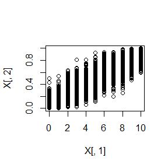

```r
bivariate <- function(a=1,b=1,n=10,N=5000){
  X = matrix(0,N,2)
  X[1,] = c(0,0.5)
  for (i in 2:N){
    y = X[i-1,2]
    X[i,1] = rbinom(1,n,y)
    x = X[i,1]
    X[i,2] = rbeta(1,x+a,n-x+b)
  }
  return(X)
}

X = bivariate()
plot(X[,1],X[,2])
```

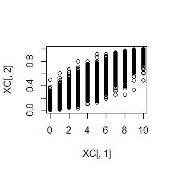

```r
# Rcpp
# Define function "add"
sourceCpp(code='
#include <Rcpp.h>
using namespace Rcpp;

//[[Rcpp::export]]
NumericMatrix bivariateC(double a, double b, int n, int N) {
  NumericMatrix X(N,2);
  double x,y;
  X(0,0)=0;
  X(0,1)=0.5;
  for(int i=1;i<N;i++){
    y = X(i-1,1);
    X(i,0) = rbinom(1,n,y)[0];
    x = X(i,0);
    X(i,1) = rbeta(1,x+a,n-x+b)[0];
  }
  return X;
}
')
XC = bivariateC(1,1,10,5000)
plot(XC[,1],XC[,2])
```

```r
ts <- microbenchmark(bivariateR=bivariate(),bivariateC=bivariateC(1,1,10,5000))
summary(ts)[,c(1,3,5,6)]
```

```
##         expr       lq   median       uq
## 1 bivariateR 19.59315 23.71785 26.39360
## 2 bivariateC  2.00930  2.10990  2.54085
```